# A3: SPL Library Checkouts

Tyler Vuu

2023

### Introduction

The data set I chose was with items that have been checked out at least 10 times a month from 2017 - 2023. With this investigation, I hope to see what trends emerge in terms of the popularity of certain books being checked out such as popular genres, authors, and media types. Through this investigation, we will be able to see what is most popular at the Seattle public library and we can use this data to be able to predict the demand for and what to order accordingly.

### Summary Information

For my summary.r script, I answered the following questions below in order to get a better idea of the data.

- What is the average number of checkouts for each item every year
- What is the top 5 most popular media type checked out
- Who is the most popular author being checked out
- How has the number of print book checkouts changed over time?
- How has the number of Ebook checkouts changed over time?

For the first question, I wanted to find this to get an idea of how often the more popular (> 10) books are being checked out for every year. For the second question we wanted to ask this in lead up to one of our other graphs so we could narrow down the library’s top 5 most popular media types when graphing. Question 3 I wanted to find as it may give insight into trends of authors throughout the years and also lead to easier graphing later on to see whether top 5 most popular authors checkouts fluctuate throughout the years. Much like question 1, question 4 asks a similar question for checkouts every year except we wanted to look at print books to see how events like the pandemic effected checkouts. Finally I wanted to see Ebook checkouts every year as later on in the report we would be comparing print and digital books later on.

```
## [1] "The average checkouts every year are:"
```

```
## [1] "22.2462020676929" "23.3982789605551" "23.5805938051677" "25.2775582752455"
## [5] "23.5387275911535" "23.5015106901509" "24.4628991859737"
```

```
## [1] "The top 5 most popular media types are:"
```

```
## [1] "EBOOK"     "AUDIOBOOK" "VIDEODISC" "SOUNDDISC" "MAGAZINE"
```

```
## [1] "The top 5 most popular authors are:"
```

```
## [1] "Willems, Mo"               "Pilkey, Dav, 1966-"
## [3] "Davis, Jim, 1945 July 28-" "Lee Child"
## [5] "Michael Connelly"
```

[output not shown]

```
## [1] "1447823" "1527112" "1490783" "363157"  "639460"  "844552"  "85080"
```

[output not shown]

```
## [1] "440127"  "597248"  "777077"  "1080133" "1043391" "1015359" "99883"
```

### The Dataset

This dataset was collected and published by the Seattle public library on January 31st, 2017. The data set is filtered down to only items at he Seattle Pacific Library that have been checked out 10 or more times and goes back to checkouts by title for physical and digital items as early as 2017. This data collected inclues the checkout tool, material type, checkout year, checkout month, physical or digital, number of times item has been checkout, the title of the item, and the author of the item. This data was collected likely to catalog which books were being checked out and at what time so the Seattle public library would know how and when books were being checked out. Before working with this data, we needed to consider the potential privacy issue of viewing other peoples checkouts and to also take care to ensure our data collected from this dataset is not misinterpreted. Some problems with this data set is that there are bits of missing data for many titles making the data incomplete in some areas. Another limitation is that this is merely the data for a single library meaning that investigations focusing on overall trends of libraries in general may be misleading as the data may be a product of the area.

### Popular Media Types Graph

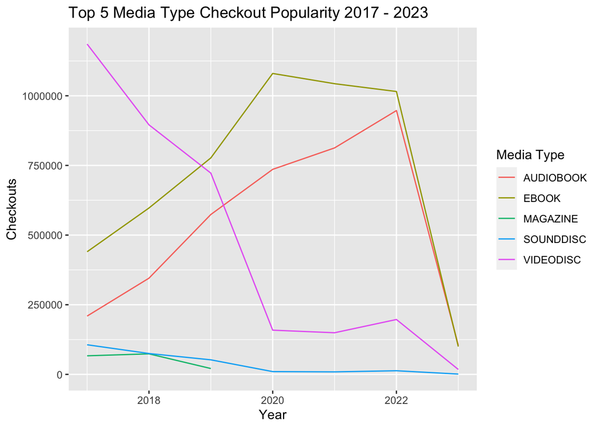

### Popular Authors Graph

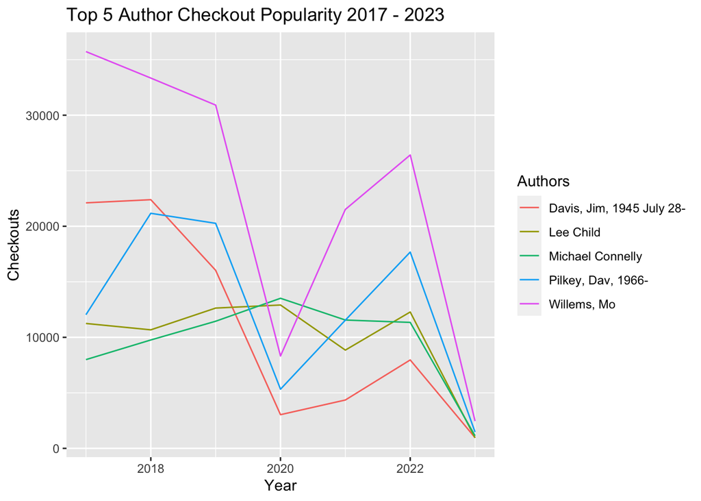

Next I wanted to see how certain authors would fare overtime as I took the top 5 most popular authors at the library to see if they would fluctuate. Overall they swapped ranks here and then with Jim Davis seemingly decreasing dramatically in popularity. But one interesting data point being 2020 as 3 authors lost a lot of check outs while the other two stayed relatively unaffected. This may be due to some authors faring better with physical material rather than digital material and as we will see in our next graph, digital was extremely popular during the pandemic.

### Physical v Digital Checkouts Graph

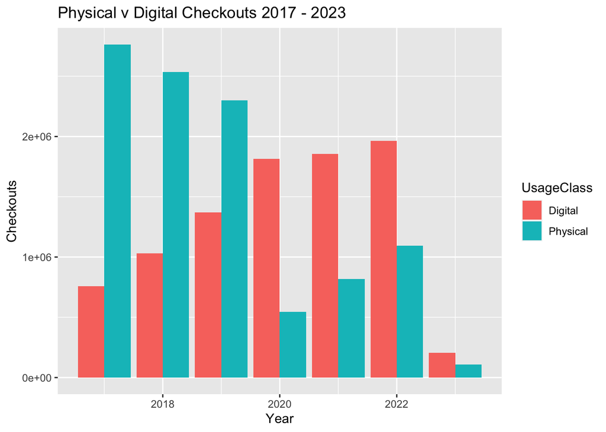